# Soccer Player Data Analysis

https://www.kaggle.com/datasets/maso0dahmed/football-players-data?resource=download

**Step 1:** Understand the dataset

**Step 2:** Importing dataset

The dataset is imported to panda datframe which is in CSV format and use matplotlib to visualise data.

**Step 3:** Data selection and reducing duplicacy

**Step 4:** Answering questions and data visualization

Now I will answer the 8 questions I made for the dataset and use matplot to visualize it.

**Questions:**

1. How are players distributed across different nationalities?
2. Top 10 nationalities with most players.
3. Which national teams have the most players in the dataset?
4. What is the age distribution among the players in the dataset?
5. Player International ratings top 10?
6. Best rating players from each country.
7. How does a player's potential rating compare to their current overall rating?
8. Does a player’s preferred foot (left or right) have any correlation with their overall performance or specific skills?

```python
import pandas as pd
import matplotlib.pyplot as plt
import numpy as np
```

```python
data = pd.read_csv('fifa_players.csv')
```

```python
data.drop_duplicates(inplace=True)
```

```python
print(data.columns)
```

```
Index(['name', 'full_name', 'birth_date', 'age', 'height_cm', 'weight_kgs',
       'positions', 'nationality', 'overall_rating', 'potential', 'value_euro',
       'wage_euro', 'preferred_foot', 'international_reputation(1-5)',
       'weak_foot(1-5)', 'skill_moves(1-5)', 'body_type',
       'release_clause_euro', 'national_team', 'national_rating',
       'national_team_position', 'national_jersey_number', 'crossing',
       'finishing', 'heading_accuracy', 'short_passing', 'volleys',
       'dribbling', 'curve', 'freekick_accuracy', 'long_passing',
       'ball_control', 'acceleration', 'sprint_speed', 'agility', 'reactions',
       'balance', 'shot_power', 'jumping', 'stamina', 'strength', 'long_shots',
       'aggression', 'interceptions', 'positioning', 'vision', 'penalties',
       'composure', 'marking', 'standing_tackle', 'sliding_tackle'],
      dtype='object')
```

```python
print(data.head(5))
```

```
           name                       full_name birth_date  age  height_cm  \
0      L. Messi  Lionel Andrés Messi Cuccittini  6/24/1987   31     170.18
1    C. Eriksen    Christian  Dannemann Eriksen  2/14/1992   27     154.94
2      P. Pogba                      Paul Pogba  3/15/1993   25     190.50
3    L. Insigne                 Lorenzo Insigne   6/4/1991   27     162.56
4  K. Koulibaly               Kalidou Koulibaly  6/20/1991   27     187.96

   weight_kgs  positions nationality  overall_rating  potential  ...  \
0        72.1   CF,RW,ST   Argentina              94         94  ...
1        76.2  CAM,RM,CM     Denmark              88         89  ...
2        83.9     CM,CAM      France              88         91  ...
3        59.0      LW,ST       Italy              88         88  ...
4        88.9         CB     Senegal              88         91  ...

   long_shots  aggression interceptions  positioning  vision  penalties  \
0          94          48            22           94      94         75
1          89          46            56           84      91         67
2          82          78            64           82      88         82
3          84          34            26           83      87         61
4          15          87            88           24      49         33

  composure  marking standing_tackle  sliding_tackle
0        96       33              28              26
1        88       59              57              22
2        87       63              67              67
3        83       51              24              22
4        80       91              88              87

[5 rows x 51 columns]
```

```python
print(data.tail(5))
```

```
                 name                         full_name birth_date  age  \
17949     R. McKenzie                    Rory  McKenzie  10/7/1993   25
17950       M. Sipľak                     Michal Sipľak   2/2/1996   23
17951      J. Bekkema                       Jan Bekkema   4/9/1996   22
17952      A. Al Yami               Abdulrahman Al Yami  6/19/1997   21
17953  Júnior Brumado  José Francisco dos Santos Júnior  5/15/1999   19

       height_cm  weight_kgs  positions   nationality  overall_rating  \
17949     175.26        74.8  RM,CAM,CM      Scotland              67
17950     182.88        79.8         LB      Slovakia              59
17951     185.42        89.8         GK   Netherlands              59
17952     175.26        64.9      ST,LM  Saudi Arabia              59
17953     190.50        79.8         ST        Brazil              59

       potential  ...  long_shots  aggression interceptions  positioning  \
17949         70  ...          54          69            41           60
17950         67  ...          22          62            55           42
17951         67  ...           9          27            10            5
17952         71  ...          58          38            15           54
17953         75  ...          53          67            20           53

       vision  penalties composure  marking standing_tackle  sliding_tackle
17949      64         63        56       40              20              18
17950      39         32        52       53              64              60
17951      25         16        47        9              12              13
17952      52         50        53       16              18              17
17953      49         52        45       23              31              21

[5 rows x 51 columns]
```

```python
print(data.shape)
```

```
(17954, 51)
```

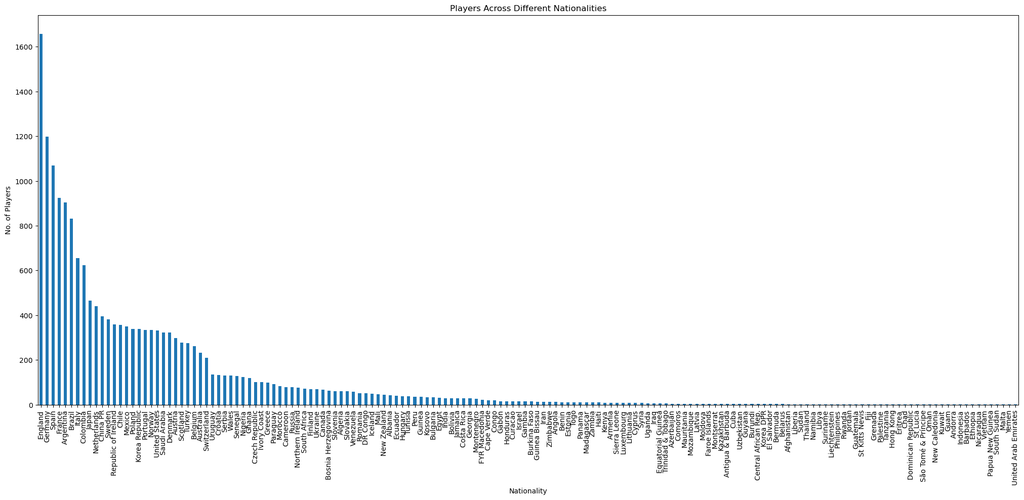

```python
#Q1
nat = data['nationality'].value_counts()
nat.plot(kind='bar', figsize=(25, 10))
plt.title('Players Across Different Nationalities')
plt.xlabel('Nationality')
plt.ylabel('No. of Players')
plt.show()
```

```python
#Q2
result = data.groupby('nationality')['nationality'].count().reset_index(name='count')
result = result.sort_values(by='count', ascending=False).head(10)
print(result)
```

```
     nationality  count
44       England   1658
57       Germany   1199
133        Spain   1070
53        France    925
6      Argentina    904
18        Brazil    832
76         Italy    655
29      Colombia    624
79         Japan    466
104  Netherlands    441
```

```python
#Q3
team_res = data.groupby('national_team')['national_team'].count().reset_index(name='count')
team_res = team_res.sort_values(by='count', ascending=False).head(10)
print(team_res)
```

```
       national_team  count
31           Denmark     23
11            Brazil     23
83          Scotland     23
86             Spain     23
44           Germany     23
43            France     23
35           England     23
93     United States     23
61       Netherlands     23
65  Northern Ireland     22
```

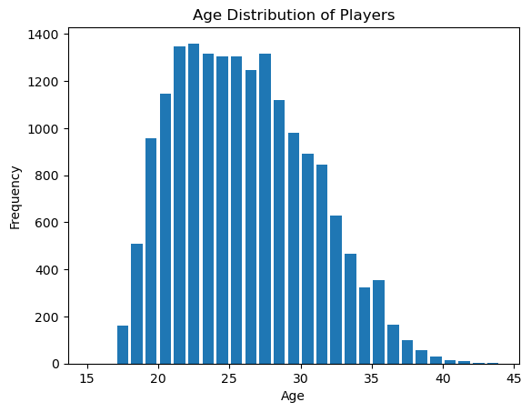

```python
#Q4
age = data['age']
age.plot(kind='hist', bins=range(15, 45), rwidth=0.8)
plt.title('Age Distribution of Players')
plt.xlabel('Age')
plt.ylabel('Frequency')
plt.show()
```

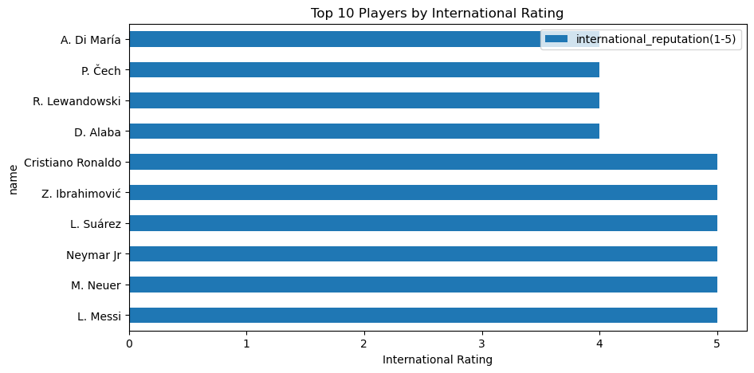

```python
#Q5
inter_rat = data[['name', 'international_reputation(1-5)']].sort_values(by='international_reputation(1-5)', ascending=False).head(10)
inter_rat.set_index('name', inplace=True)
inter_rat.plot(kind='barh', figsize=(10, 5))
plt.title('Top 10 Players by International Rating')
plt.xlabel('International Rating')
plt.show()
```

```python
#Q6
best_plr = data.loc[data.groupby('nationality')['overall_rating'].idxmax()]
best_plr = best_plr[['nationality', 'name', 'overall_rating']]
best_plr_asc = best_plr.sort_values(by='overall_rating', ascending=False).reset_index(drop=True)
print(best_plr_asc)
```

```
          nationality               name  overall_rating
0            Portugal  Cristiano Ronaldo              94
1           Argentina           L. Messi              94
2              Brazil          Neymar Jr              92
3             Belgium          E. Hazard              91
4               Spain             De Gea              91
..                ...                ...             ...
155         Hong Kong           F. Baise              61
156  Papua New Guinea        A. Komolong              61
157       South Sudan           K. Athiu              60
158             Yemen        A. Ba Saeed              58
159         Indonesia   E. Maulana Vikri              56

[160 rows x 3 columns]
```

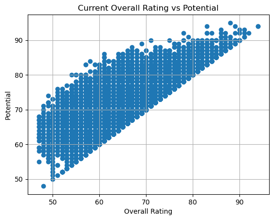

```python
#Q7
plt.scatter(data['overall_rating'], data['potential'])
plt.title('Current Overall Rating vs Potential')
plt.xlabel('Overall Rating')
plt.ylabel('Potential')
plt.grid(True)
plt.show()
```

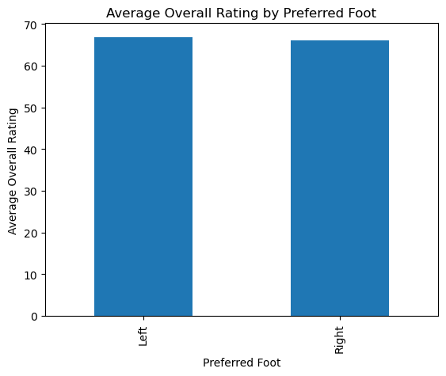

```python
#Q8
foot = data.groupby('preferred_foot')['overall_rating'].mean()
foot.plot(kind='bar')
plt.title('Average Overall Rating by Preferred Foot')
plt.xlabel('Preferred Foot')
plt.ylabel('Average Overall Rating')
plt.show()
```

I've discovered some important patterns in my examination of the FIFA football players dataset that show how talented football players are distributed throughout the world. I learned which nations produce the best athletes and which teams are well-known for developing such talent. Furthermore, I learned more about the individual standouts by examining the top-rated players from each nation, which is essential for comprehending the dynamics of the player market.

All things considered, these revelations enhance my comprehension of the global dynamics of football and the growth of players, thereby enhancing my academic endeavors in sports studies.